# hw2_fintech

Ruizhou Peng

2023-10-16

To begin, install the ‘quantmod’ package and load stock price data from Yahoo Finance.

```r
library(quantmod)
library(tidyverse)
getSymbols('AAPL', src = 'yahoo')
```

```
## [1] "AAPL"
```

```r
df_AAPL <- data.frame(Date=as.character(index(AAPL)), coredata(AAPL))
```

## 1.Data Wrangling

q1: inspect the dataset with **head**, and check if there is any NA value in each column

```r
df_AAPL %>% head(5)
```

```
##         Date AAPL.Open AAPL.High AAPL.Low AAPL.Close AAPL.Volume AAPL.Adjusted
## 1 2007-01-03  3.081786  3.092143 2.925000   2.992857  1238319600      2.540327
## 2 2007-01-04  3.001786  3.069643 2.993571   3.059286   847260400      2.596711
## 3 2007-01-05  3.063214  3.078571 3.014286   3.037500   834741600      2.578220
## 4 2007-01-08  3.070000  3.090357 3.045714   3.052500   797106800      2.590951
## 5 2007-01-09  3.087500  3.320714 3.041071   3.306071  3349298400      2.806182
```

```r
df_AAPL %>% summarise(across(everything(),
                             ~sum(is.na(.))))
```

```
##   Date AAPL.Open AAPL.High AAPL.Low AAPL.Close AAPL.Volume AAPL.Adjusted
## 1    0         0         0        0          0           0             0
```

q2: load stock price of MicroSoft using ticker “MS”, transfer to data frame and combine the stock price of MS and AAPL into one data frame df_all. Select Date, Open and Close price of two stocks.

```r
# first load MicroSoft stock
# coredata--->extract the observation without time series
getSymbols('MS', src= 'yahoo')
```

```
## [1] "MS"
```

```r
df_MS <- data.frame(Date=as.character(index(MS)), coredata(MS))
```

```r
# use join to combine the stock price of MS,AAPL
# into one data frame

df_all <- df_AAPL%>%select(Date, AAPL.Open, AAPL.Close) %>%
  inner_join(df_MS%>%select(Date, MS.Open, MS.Close))
```

check

```r
df_all %>% head(5)
```

```
##         Date AAPL.Open AAPL.Close MS.Open MS.Close
## 1 2007-01-03  3.081786   2.992857   81.93    81.62
## 2 2007-01-04  3.001786   3.059286   81.27    81.91
## 3 2007-01-05  3.063214   3.037500   81.35    80.86
## 4 2007-01-08  3.070000   3.052500   80.61    81.35
## 5 2007-01-09  3.087500   3.306071   81.20    81.16
```

## 2. Data Wrangling and Visualization

q3: caculate the intraday return into {stockname}.R

```r
df_all <- df_all %>% mutate(AAPL.R= (AAPL.Close-AAPL.Open)/AAPL.Open)


df_all <- df_all %>% mutate(MS.R= (MS.Close-MS.Open)/MS.Open)
```

q4: plot the density of AAPL.R using **ggplot** and **geom_density**

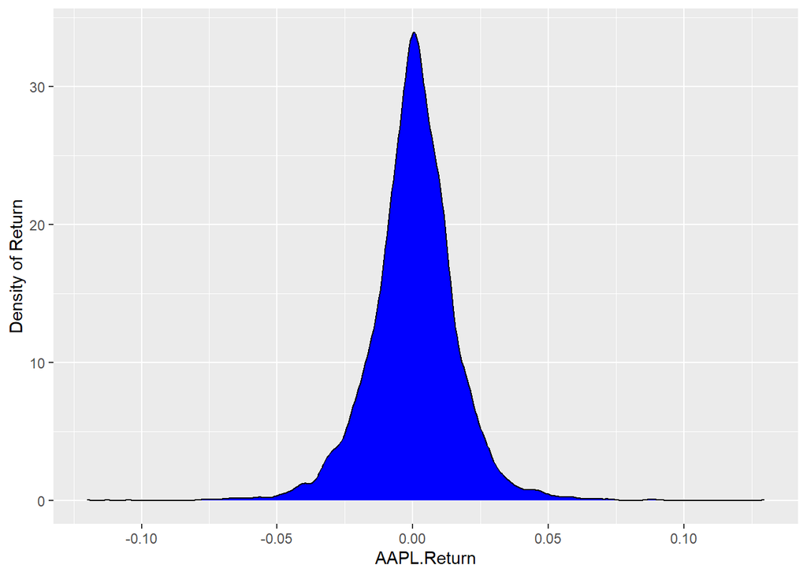

```r
# use 'fill' arg to control filling color
df_all%>%ggplot(aes(AAPL.R))+geom_density(fill='blue')+xlab('AAPL.Return')+ylab('Density of Return')
```

q5: we need to extract the information of stock performance by year. First split column **Date** into “Year”, “Month” and “Day” and create a new frame called **df_ymd** transformed by **df_all**

```r
df_ymd <- df_all%>%
  separate(Date, c("Year", "Month", "Day"), sep='-')
```

check

```r
df_ymd %>% head(5)
```

```
##   Year Month Day AAPL.Open AAPL.Close MS.Open MS.Close       AAPL.R
## 1 2007    01  03  3.081786   2.992857   81.93    81.62 -0.028856300
## 2 2007    01  04  3.001786   3.059286   81.27    81.91  0.019155304
## 3 2007    01  05  3.063214   3.037500   81.35    80.86 -0.008394503
## 4 2007    01  08  3.070000   3.052500   80.61    81.35 -0.005700301
## 5 2007    01  09  3.087500   3.306071   81.20    81.16  0.070792208
##            MS.R
## 1 -0.0037836880
## 2  0.0078750713
## 3 -0.0060233297
## 4  0.0091799759
## 5 -0.0004925282
```

q6: create a boxplot of MS.R using **ggplot** and **geom_boxplot**. To distinguish returns across different years, utilize the **aes()**

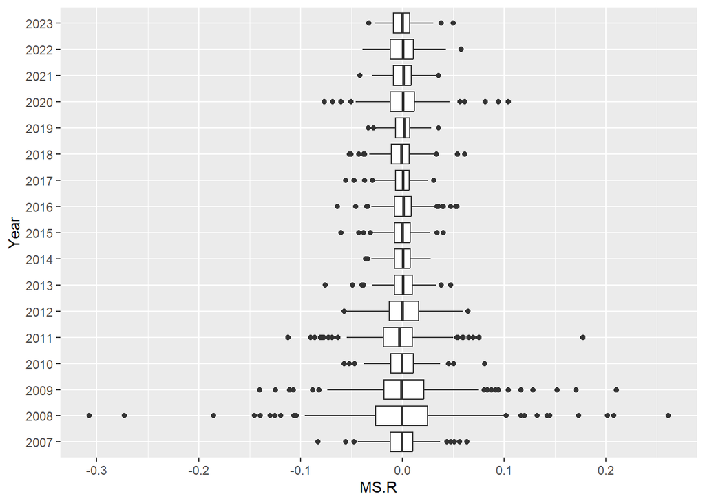

```r
df_ymd %>%
  ggplot(aes(x=MS.R, y=Year))+geom_boxplot()
```

From this boxplot, we can see that the inner quartile range is shrinking across the year while the median of the returns stay steady nearly 0. The abnormal movements in the stock may lie in 2008 since it has a wide IQR and there are a lot of outliers, this phenomenon may reflect that the stock is going through some changes and is fluctuating.

## 3. Data Wrangling, Tidying and Visualization

q7: create a frame **df_sum** for the stocks’ average return over months during 2000-2020

```r
df_sum <- df_ymd%>%
  filter(Year>=2000 & Year<= 2020)%>%
  select(Month, AAPL.R, MS.R)%>%
  group_by(Month)%>%
  summarise(AAPL.Mn=mean(AAPL.R, na.rm=TRUE),
            MS.Mn = mean(MS.R, na.rm=TRUE))
```

check

```r
df_sum %>% head(5)
```

```
## # A tibble: 5 × 3
##   Month   AAPL.Mn       MS.Mn
##   <chr>     <dbl>       <dbl>
## 1 01    -0.00113   0.00232
## 2 02     0.00158  -0.00000973
## 3 03     0.00146   0.000288
## 4 04     0.000548  0.000224
## 5 05     0.00146   0.000253
```

q8: tidy df_sum since the columns, and generate bar-chart for AAPL.Mn and Ms.Mn over months [non-tidy since columns represent a single variable]

```r
# utilize pivot_longer to transform columns to a single column: Stock
long_df <- df_sum %>%
  pivot_longer(!Month ,names_to = 'Stock', values_to = 'Returns')
```

check

```r
long_df %>% head(10)
```

```
## # A tibble: 10 × 3
##    Month Stock       Returns
##    <chr> <chr>         <dbl>
##  1 01    AAPL.Mn -0.00113
##  2 01    MS.Mn    0.00232
##  3 02    AAPL.Mn  0.00158
##  4 02    MS.Mn   -0.00000973
##  5 03    AAPL.Mn  0.00146
##  6 03    MS.Mn    0.000288
##  7 04    AAPL.Mn  0.000548
##  8 04    MS.Mn    0.000224
##  9 05    AAPL.Mn  0.00146
## 10 05    MS.Mn    0.000253
```

then use **ggplot** to show bar-chart over different months

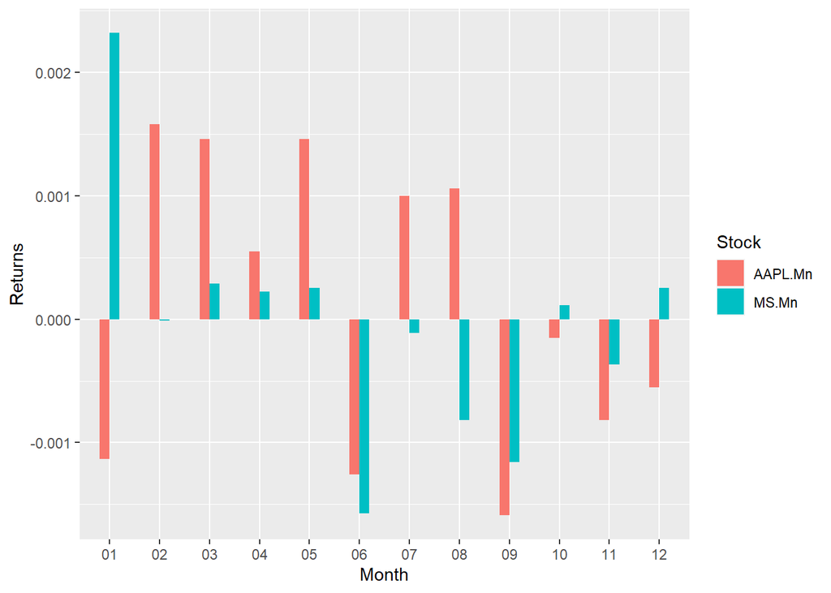

```r
# ggplot:
#   fill---> filling the color according to the specified column
#     using different values in the column

# position_dodge:
#   adjusting the horizontal position,need to be specified in the
#   global or geom* layer
#   usage: position= position_dodge(width=?)

long_df %>%
  ggplot(aes(x=Month, y=Returns, fill=Stock))+
  geom_col(position = position_dodge(width = 0.4), width=0.4)
```